# hw5

Ritika Agrawal

April 10, 2020

## Liquor Sales in Iowa

This dataset https://data.iowa.gov/Sales-Distribution/2019-Iowa-Liquor-Sales/38x4-vs5h contains the spirits purchase information of Iowa Class “E” liquor licensees by product and date of purchase for 2019. The dataset can be used to analyze total spirits sales in Iowa of individual products at the store level.

**Submission instructions**: Create a folder named `ds202_hw5`, and name the RMarkDown file including your solutions `hw5.Rmd` under this folder. For the submission, create a GitHub repository named `ds202_hw5` under your GitHub account, and push both `hw5.Rmd` and the knitted `hw5.html` before the deadline. I will assume you use the same GitHub username as for your HW4 submission. The latest version of your homework appearing on GitHub before the deadline is graded. *It is crucial to follow the exact folder structure and file names*, so that your homework can be reproduced and graded by an automated script. This homework is **due on April 10** by 11:59 pm.

1. The complete dataset is too large. Download and import the alcohol sales data for Ames only:
1. Go to https://data.iowa.gov/Sales-Distribution/2019-Iowa-Liquor-Sales/38x4-vs5h
2. Click Filter – Filter – Go advanced now
3. Add a New Filter Condition: City is Ames.
4. Export – CSV – Download
5. Use `readr::read_csv` to import.

```r
library(tidyr)
library(readr)
library(dplyr)
liq_sales <- read_csv("2019_Iowa_Liquor_Sales.csv")
head(liq_sales)
```

```
## # A tibble: 6 x 24
##   `Invoice/Item N~ Date  `Store Number` `Store Name` Address City  `Zip Code`
##   <chr>            <chr>          <dbl> <chr>        <chr>   <chr>      <dbl>
## 1 INV-16712000040  01/0~           2500 Hy-Vee Food~ 3800 W~ Ames       50010
## 2 INV-16712000012  01/0~           2500 Hy-Vee Food~ 3800 W~ Ames       50010
## 3 INV-16712000070  01/0~           2500 Hy-Vee Food~ 3800 W~ Ames       50010
## 4 INV-16712000009  01/0~           2500 Hy-Vee Food~ 3800 W~ Ames       50010
## 5 INV-16712000160  01/0~           2500 Hy-Vee Food~ 3800 W~ Ames       50010
## 6 INV-16712000119  01/0~           2500 Hy-Vee Food~ 3800 W~ Ames       50010
## # ... with 17 more variables: `Store Location` <chr>, `County Number` <dbl>,
## #   County <chr>, Category <dbl>, `Category Name` <chr>, `Vendor Number` <chr>,
## #   `Vendor Name` <chr>, `Item Number` <dbl>, `Item Description` <chr>,
## #   Pack <dbl>, `Bottle Volume (ml)` <dbl>, `State Bottle Cost` <dbl>, `State
## #   Bottle Retail` <dbl>, `Bottles Sold` <dbl>, `Sale (Dollars)` <dbl>, `Volume
## #   Sold (Liters)` <dbl>, `Volume Sold (Gallons)` <dbl>
```

2. Data cleaning:
1. extract geographic latitude and longitude from the variable `Store Location`
2. make sure the variables are in the correct type, by converting incorrect variable types.
3. extract year, month and day from the variable `Date` as separate columns.

```r
liq_sales$long = substr(liq_sales$`Store Location`,8,17)
liq_sales$lat = substr(liq_sales$`Store Location`,18,27)
liq_sales
```

```
## # A tibble: 63,103 x 26
##    `Invoice/Item N~ Date  `Store Number` `Store Name` Address City  `Zip Code`
##    <chr>            <chr>          <dbl> <chr>        <chr>   <chr>      <dbl>
##  1 INV-16712000040  01/0~           2500 Hy-Vee Food~ 3800 W~ Ames       50010
##  2 INV-16712000012  01/0~           2500 Hy-Vee Food~ 3800 W~ Ames       50010
##  3 INV-16712000070  01/0~           2500 Hy-Vee Food~ 3800 W~ Ames       50010
##  4 INV-16712000009  01/0~           2500 Hy-Vee Food~ 3800 W~ Ames       50010
##  5 INV-16712000160  01/0~           2500 Hy-Vee Food~ 3800 W~ Ames       50010
##  6 INV-16712000119  01/0~           2500 Hy-Vee Food~ 3800 W~ Ames       50010
##  7 INV-16712000153  01/0~           2500 Hy-Vee Food~ 3800 W~ Ames       50010
##  8 INV-16712000114  01/0~           2500 Hy-Vee Food~ 3800 W~ Ames       50010
##  9 INV-16834400018  01/0~           4251 AJ's Liquor~ 4518 M~ Ames       50014
## 10 INV-16834600031  01/0~           2500 Hy-Vee Food~ 3800 W~ Ames       50010
## # ... with 63,093 more rows, and 19 more variables: `Store Location` <chr>,
## #   `County Number` <dbl>, County <chr>, Category <dbl>, `Category Name` <chr>,
## #   `Vendor Number` <chr>, `Vendor Name` <chr>, `Item Number` <dbl>, `Item
## #   Description` <chr>, Pack <dbl>, `Bottle Volume (ml)` <dbl>, `State Bottle
## #   Cost` <dbl>, `State Bottle Retail` <dbl>, `Bottles Sold` <dbl>, `Sale
## #   (Dollars)` <dbl>, `Volume Sold (Liters)` <dbl>, `Volume Sold
## #   (Gallons)` <dbl>, long <chr>, lat <chr>
```

```r
liq_sales$date_1 = substr(liq_sales$Date,1,1)
liq_sales$month = substr(liq_sales$Date,5,5)
liq_sales$year = substr(liq_sales$Date,5,10)

liq_sales
```

```
## # A tibble: 63,103 x 29
##    `Invoice/Item N~ Date  `Store Number` `Store Name` Address City  `Zip Code`
##    <chr>            <chr>          <dbl> <chr>        <chr>   <chr>      <dbl>
##  1 INV-16712000040  01/0~           2500 Hy-Vee Food~ 3800 W~ Ames       50010
##  2 INV-16712000012  01/0~           2500 Hy-Vee Food~ 3800 W~ Ames       50010
##  3 INV-16712000070  01/0~           2500 Hy-Vee Food~ 3800 W~ Ames       50010
##  4 INV-16712000009  01/0~           2500 Hy-Vee Food~ 3800 W~ Ames       50010
##  5 INV-16712000160  01/0~           2500 Hy-Vee Food~ 3800 W~ Ames       50010
##  6 INV-16712000119  01/0~           2500 Hy-Vee Food~ 3800 W~ Ames       50010
##  7 INV-16712000153  01/0~           2500 Hy-Vee Food~ 3800 W~ Ames       50010
##  8 INV-16712000114  01/0~           2500 Hy-Vee Food~ 3800 W~ Ames       50010
##  9 INV-16834400018  01/0~           4251 AJ's Liquor~ 4518 M~ Ames       50014
## 10 INV-16834600031  01/0~           2500 Hy-Vee Food~ 3800 W~ Ames       50010
## # ... with 63,093 more rows, and 22 more variables: `Store Location` <chr>,
## #   `County Number` <dbl>, County <chr>, Category <dbl>, `Category Name` <chr>,
## #   `Vendor Number` <chr>, `Vendor Name` <chr>, `Item Number` <dbl>, `Item
## #   Description` <chr>, Pack <dbl>, `Bottle Volume (ml)` <dbl>, `State Bottle
## #   Cost` <dbl>, `State Bottle Retail` <dbl>, `Bottles Sold` <dbl>, `Sale
## #   (Dollars)` <dbl>, `Volume Sold (Liters)` <dbl>, `Volume Sold
## #   (Gallons)` <dbl>, long <chr>, lat <chr>, date_1 <chr>, month <chr>,
## #   year <chr>
```

3. First overview:
1. Plot a scatterplot of lat and long of store locations.

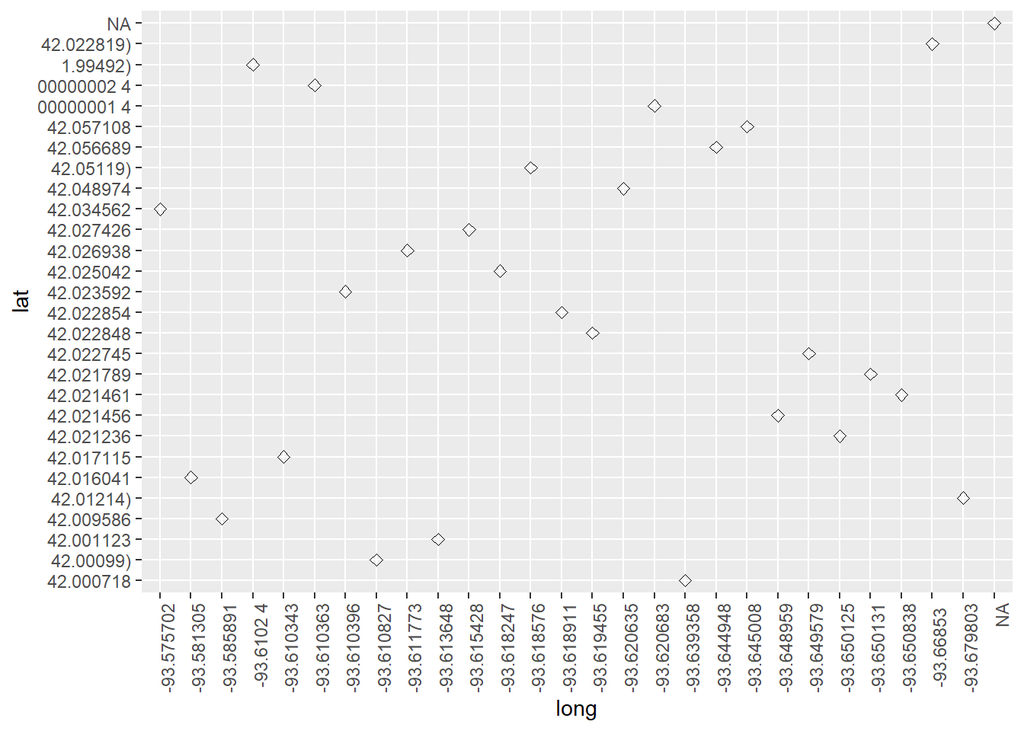

```r
library(ggplot2)

ggplot(liq_sales, aes(x=long, y=lat)) +
  geom_point(size=2, shape=23) +
  theme(axis.text.x = element_text(angle = 90, hjust = 1))
```

2. Provide a visual breakdown of the liquor category (by `Category Name`). Include volume sold in the breakdown.

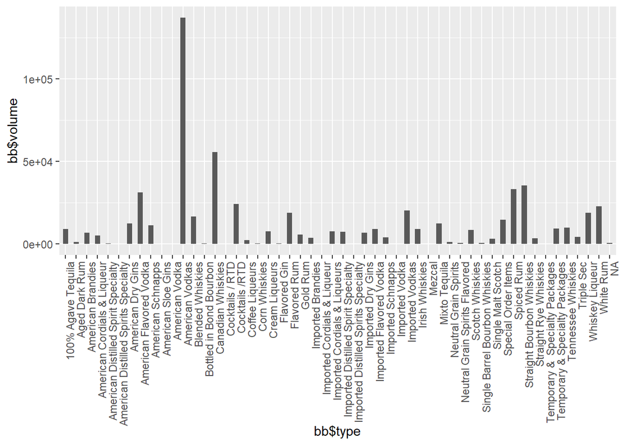

```r
bb= liq_sales %>%
  group_by(liq_sales$`Category Name`) %>%
  summarize(volume = sum(`Volume Sold (Liters)`, na.rm = TRUE))
colnames(bb) <- c("type","volume")
ggplot(data=bb, aes(x=bb$type, y=bb$volume)) +
  geom_bar(stat="identity", width=0.5)+
  theme(axis.text.x = element_text(angle = 90, hjust = 1))
```

4. Find the daily sales liquor sales in Ames in 2019. Summarize the number of sales, volume of liquor sold, and amount of money spent.

```r
number_of_sales <- nrow(liq_sales)
number_of_sales
```

```
## [1] 63103
```

```r
volume_of_liq_sold <- sum(liq_sales$`Volume Sold (Liters)`)
volume_of_liq_sold
```

```
## [1] 590873.8
```

```r
amt_of_money_spent <- sum(liq_sales$`Sale (Dollars)`)
amt_of_money_spent
```

```
## [1] 9052392
```

5. Plot volume sold by day (use a scatterplot of volume by day and facet by month). Discover trends with the help of `geom_smooth`. Describe any patterns.

```r
cc = liq_sales %>%
  group_by(liq_sales$Date) %>%
  summarize(volume = sum(`Volume Sold (Liters)`, na.rm = TRUE))
cc
```

```
## # A tibble: 157 x 2
##    `liq_sales$Date` volume
##    <chr>             <dbl>
##  1 01/03/2019        6816.
##  2 01/04/2019        1256.
##  3 01/09/2019        6732.
##  4 01/10/2019         135
##  5 01/11/2019        1205.
##  6 01/16/2019        8227.
##  7 01/18/2019         232.
##  8 01/24/2019        9239.
##  9 01/25/2019        2329.
## 10 01/30/2019        8752.
## # ... with 147 more rows
```

```r
colnames(cc) <- c("Day","volume")
cc$month = substr(cc$Day,1,2)
cc
```

```
## # A tibble: 157 x 3
##    Day        volume month
##    <chr>       <dbl> <chr>
##  1 01/03/2019  6816. 01
##  2 01/04/2019  1256. 01
##  3 01/09/2019  6732. 01
##  4 01/10/2019   135  01
##  5 01/11/2019  1205. 01
##  6 01/16/2019  8227. 01
##  7 01/18/2019   232. 01
##  8 01/24/2019  9239. 01
##  9 01/25/2019  2329. 01
## 10 01/30/2019  8752. 01
## # ... with 147 more rows
```

[figure not shown]

```r
ggplot(data=cc, aes(x=cc$Day, y=cc$volume)) +
  geom_bar(stat="identity", width=0.5)+
  theme(axis.text.x = element_text(angle = 90, hjust = 1))+ facet_grid(rows = vars(month)) + geom_smooth()
```

6. Find the dates for ISU football home games in Fall 2019. Can you see a pattern?

```r
games=subset(liq_sales, liq_sales$Date == "09/28/2019" & liq_sales$Date == "10/05/2019" & liq_sales$Date == "10/12/2019" & liq_sales$Date == "10/19/2019" & liq_sales$Date == "10/26/2019" & liq_sales$Date == "11/09/2019" & liq_sales$Date == "11/16/2019" & liq_sales$Date == "11/23/2019" & liq_sales$Date == "11/30/2019" & liq_sales$Date == "12/28/2019")
games
```

```
## # A tibble: 0 x 29
## # ... with 29 variables: `Invoice/Item Number` <chr>, Date <chr>, `Store
## #   Number` <dbl>, `Store Name` <chr>, Address <chr>, City <chr>, `Zip
## #   Code` <dbl>, `Store Location` <chr>, `County Number` <dbl>, County <chr>,
## #   Category <dbl>, `Category Name` <chr>, `Vendor Number` <chr>, `Vendor
## #   Name` <chr>, `Item Number` <dbl>, `Item Description` <chr>, Pack <dbl>,
## #   `Bottle Volume (ml)` <dbl>, `State Bottle Cost` <dbl>, `State Bottle
## #   Retail` <dbl>, `Bottles Sold` <dbl>, `Sale (Dollars)` <dbl>, `Volume Sold
## #   (Liters)` <dbl>, `Volume Sold (Gallons)` <dbl>, long <chr>, lat <chr>,
## #   date_1 <chr>, month <chr>, year <chr>
```

Note: your submission is supposed to be fully reproducible, i.e. the TA and I will ‘knit’ your submission in RStudio.